# Risk Factor Analysis

## Outcome Variable

**Outcome Variable:** ever_stunted

## Predictor Variables

**Intervention Variable:** fhtcm

**Adjustment Set:**

- arm
- W_mage
- W_fage
- meducyrs
- feducyrs
- W_mhtcm
- W_mwtkg
- W_mbmi
- single
- delta_W_mage
- delta_W_fage
- delta_meducyrs
- delta_feducyrs
- delta_W_mhtcm
- delta_W_mwtkg
- delta_W_mbmi
- delta_single

## Stratifying Variables

The analysis was stratified on these variable(s):

- agecat
- studyid
- country

## Data Summary

| agecat | studyid | country | fhtcm | ever_stunted | n_cell | n |
| --- | --- | --- | --- | --- | --- | --- |
| 0-24 months | ki1000304b-SAS-CompFeed | INDIA | >=167 cm | 0 | 137 | 907 |
| 0-24 months | ki1000304b-SAS-CompFeed | INDIA | >=167 cm | 1 | 273 | 907 |
| 0-24 months | ki1000304b-SAS-CompFeed | INDIA | <162 cm | 0 | 50 | 907 |
| 0-24 months | ki1000304b-SAS-CompFeed | INDIA | <162 cm | 1 | 180 | 907 |
| 0-24 months | ki1000304b-SAS-CompFeed | INDIA | [162-167) cm | 0 | 69 | 907 |
| 0-24 months | ki1000304b-SAS-CompFeed | INDIA | [162-167) cm | 1 | 198 | 907 |
| 0-24 months | ki1000304b-SAS-FoodSuppl | INDIA | >=167 cm | 0 | 23 | 399 |
| 0-24 months | ki1000304b-SAS-FoodSuppl | INDIA | >=167 cm | 1 | 83 | 399 |
| 0-24 months | ki1000304b-SAS-FoodSuppl | INDIA | <162 cm | 0 | 15 | 399 |
| 0-24 months | ki1000304b-SAS-FoodSuppl | INDIA | <162 cm | 1 | 148 | 399 |
| 0-24 months | ki1000304b-SAS-FoodSuppl | INDIA | [162-167) cm | 0 | 23 | 399 |
| 0-24 months | ki1000304b-SAS-FoodSuppl | INDIA | [162-167) cm | 1 | 107 | 399 |
| 0-24 months | ki1101329-Keneba | GAMBIA | >=167 cm | 0 | 598 | 1929 |
| 0-24 months | ki1101329-Keneba | GAMBIA | >=167 cm | 1 | 647 | 1929 |
| 0-24 months | ki1101329-Keneba | GAMBIA | <162 cm | 0 | 52 | 1929 |
| 0-24 months | ki1101329-Keneba | GAMBIA | <162 cm | 1 | 80 | 1929 |
| 0-24 months | ki1101329-Keneba | GAMBIA | [162-167) cm | 0 | 207 | 1929 |
| 0-24 months | ki1101329-Keneba | GAMBIA | [162-167) cm | 1 | 345 | 1929 |
| 0-24 months | ki1119695-PROBIT | BELARUS | >=167 cm | 0 | 9839 | 12537 |
| 0-24 months | ki1119695-PROBIT | BELARUS | >=167 cm | 1 | 1905 | 12537 |
| 0-24 months | ki1119695-PROBIT | BELARUS | <162 cm | 0 | 119 | 12537 |
| 0-24 months | ki1119695-PROBIT | BELARUS | <162 cm | 1 | 49 | 12537 |
| 0-24 months | ki1119695-PROBIT | BELARUS | [162-167) cm | 0 | 474 | 12537 |
| 0-24 months | ki1119695-PROBIT | BELARUS | [162-167) cm | 1 | 151 | 12537 |
| 0-24 months | ki1135781-COHORTS | GUATEMALA | >=167 cm | 0 | 16 | 496 |
| 0-24 months | ki1135781-COHORTS | GUATEMALA | >=167 cm | 1 | 48 | 496 |
| 0-24 months | ki1135781-COHORTS | GUATEMALA | <162 cm | 0 | 24 | 496 |
| 0-24 months | ki1135781-COHORTS | GUATEMALA | <162 cm | 1 | 269 | 496 |
| 0-24 months | ki1135781-COHORTS | GUATEMALA | [162-167) cm | 0 | 24 | 496 |
| 0-24 months | ki1135781-COHORTS | GUATEMALA | [162-167) cm | 1 | 115 | 496 |

[output cut: 60 more lines]

The following strata were considered:

- agecat: 0-24 months, studyid: ki1000304b-SAS-CompFeed, country: INDIA
- agecat: 0-24 months, studyid: ki1000304b-SAS-FoodSuppl, country: INDIA
- agecat: 0-24 months, studyid: ki1101329-Keneba, country: GAMBIA
- agecat: 0-24 months, studyid: ki1119695-PROBIT, country: BELARUS
- agecat: 0-24 months, studyid: ki1135781-COHORTS, country: GUATEMALA
- agecat: 0-6 months, studyid: ki1000304b-SAS-CompFeed, country: INDIA
- agecat: 0-6 months, studyid: ki1000304b-SAS-FoodSuppl, country: INDIA
- agecat: 0-6 months, studyid: ki1101329-Keneba, country: GAMBIA
- agecat: 0-6 months, studyid: ki1119695-PROBIT, country: BELARUS
- agecat: 0-6 months, studyid: ki1135781-COHORTS, country: GUATEMALA
- agecat: 6-24 months, studyid: ki1000304b-SAS-CompFeed, country: INDIA
- agecat: 6-24 months, studyid: ki1000304b-SAS-FoodSuppl, country: INDIA
- agecat: 6-24 months, studyid: ki1101329-Keneba, country: GAMBIA
- agecat: 6-24 months, studyid: ki1119695-PROBIT, country: BELARUS
- agecat: 6-24 months, studyid: ki1135781-COHORTS, country: GUATEMALA

## Methods Detail

We’re interested in the causal parameters $E[Y_a]$ for all values of $a \in \mathcal{A}$. These parameters represent the mean outcome if, possibly contrary to fact, we intervened to set all units to have $A=a$. Under the randomization and positivity assumptions, these are identified by the statistical parameters $\psi_a=E_W[E_{Y|A,W}(Y|A=a,W)]$. In addition, we’re interested in the mean of $Y$, $E[Y]$ under no intervention (the observed mean). We will estimate these parameters by using SuperLearner to fit the relevant likelihood factors – $E_{Y|A,W}(Y|A=a,W)$ and $p(A=a|W)$, and then updating our likelihood fit using a joint TMLE.

For unadjusted analyses ($W=\{\}$), initial likelihoods were estimated using Lrnr_glm to estimate the simple $E(Y|A)$ and Lrnr_mean to estimate $p(A)$. For adjusted analyses, a small library containing Lrnr_glmnet, Lrnr_xgboost, and Lrnr_mean was used.

Having estimated these parameters, we will then use the delta method to estimate relative risks and attributable risks relative to a prespecified baseline level of $A$.

# Results Detail

## Results Plots

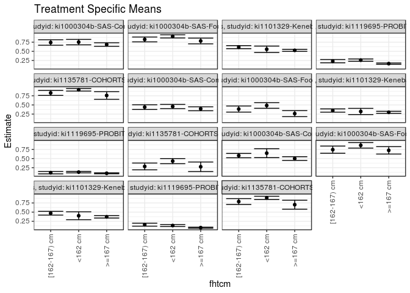

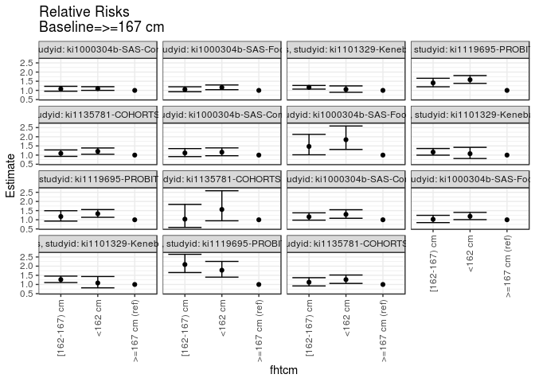

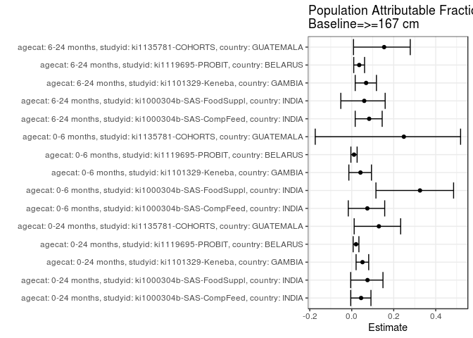

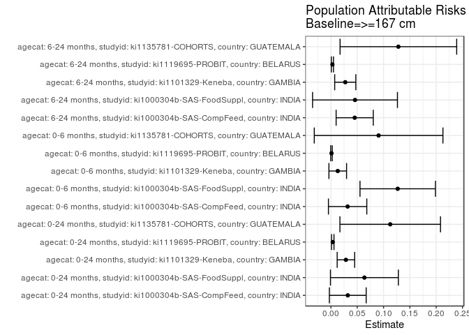

## Results Table

### Parameter: TSM

| agecat | studyid | country | intervention_level | baseline_level | estimate | ci_lower | ci_upper |
| --- | --- | --- | --- | --- | --- | --- | --- |
| 0-24 months | ki1000304b-SAS-CompFeed | INDIA | >=167 cm | NA | 0.6857409 | 0.6381518 | 0.7333301 |
| 0-24 months | ki1000304b-SAS-CompFeed | INDIA | <162 cm | NA | 0.7521131 | 0.6773973 | 0.8268290 |
| 0-24 months | ki1000304b-SAS-CompFeed | INDIA | [162-167) cm | NA | 0.7411210 | 0.6665387 | 0.8157033 |
| 0-24 months | ki1000304b-SAS-FoodSuppl | INDIA | >=167 cm | NA | 0.7834865 | 0.7049420 | 0.8620310 |
| 0-24 months | ki1000304b-SAS-FoodSuppl | INDIA | <162 cm | NA | 0.9087684 | 0.8652593 | 0.9522775 |
| 0-24 months | ki1000304b-SAS-FoodSuppl | INDIA | [162-167) cm | NA | 0.8253493 | 0.7591527 | 0.8915459 |
| 0-24 months | ki1101329-Keneba | GAMBIA | >=167 cm | NA | 0.5272557 | 0.4991837 | 0.5553277 |
| 0-24 months | ki1101329-Keneba | GAMBIA | <162 cm | NA | 0.5569011 | 0.4697468 | 0.6440554 |
| 0-24 months | ki1101329-Keneba | GAMBIA | [162-167) cm | NA | 0.6145805 | 0.5728592 | 0.6563018 |
| 0-24 months | ki1119695-PROBIT | BELARUS | >=167 cm | NA | 0.1644628 | 0.1462194 | 0.1827062 |
| 0-24 months | ki1119695-PROBIT | BELARUS | <162 cm | NA | 0.2602402 | 0.2285167 | 0.2919638 |
| 0-24 months | ki1119695-PROBIT | BELARUS | [162-167) cm | NA | 0.2319845 | 0.1873971 | 0.2765718 |
| 0-24 months | ki1135781-COHORTS | GUATEMALA | >=167 cm | NA | 0.7583037 | 0.6543767 | 0.8622306 |
| 0-24 months | ki1135781-COHORTS | GUATEMALA | <162 cm | NA | 0.9132143 | 0.8791206 | 0.9473080 |
| 0-24 months | ki1135781-COHORTS | GUATEMALA | [162-167) cm | NA | 0.8282561 | 0.7603351 | 0.8961770 |
| 0-6 months | ki1000304b-SAS-CompFeed | INDIA | >=167 cm | NA | 0.3948059 | 0.3409023 | 0.4487095 |
| 0-6 months | ki1000304b-SAS-CompFeed | INDIA | <162 cm | NA | 0.4573219 | 0.3999137 | 0.5147302 |
| 0-6 months | ki1000304b-SAS-CompFeed | INDIA | [162-167) cm | NA | 0.4404994 | 0.3762520 | 0.5047468 |
| 0-6 months | ki1000304b-SAS-FoodSuppl | INDIA | >=167 cm | NA | 0.2634780 | 0.1826296 | 0.3443264 |
| 0-6 months | ki1000304b-SAS-FoodSuppl | INDIA | <162 cm | NA | 0.4846121 | 0.4082830 | 0.5609412 |
| 0-6 months | ki1000304b-SAS-FoodSuppl | INDIA | [162-167) cm | NA | 0.3876485 | 0.3044123 | 0.4708846 |
| 0-6 months | ki1101329-Keneba | GAMBIA | >=167 cm | NA | 0.2987014 | 0.2714051 | 0.3259977 |
| 0-6 months | ki1101329-Keneba | GAMBIA | <162 cm | NA | 0.3214423 | 0.2364377 | 0.4064468 |
| 0-6 months | ki1101329-Keneba | GAMBIA | [162-167) cm | NA | 0.3474584 | 0.3033112 | 0.3916056 |
| 0-6 months | ki1119695-PROBIT | BELARUS | >=167 cm | NA | 0.0965657 | 0.0835750 | 0.1095563 |
| 0-6 months | ki1119695-PROBIT | BELARUS | <162 cm | NA | 0.1284448 | 0.1076023 | 0.1492873 |
| 0-6 months | ki1119695-PROBIT | BELARUS | [162-167) cm | NA | 0.1138390 | 0.0814473 | 0.1462308 |
| 0-6 months | ki1135781-COHORTS | GUATEMALA | >=167 cm | NA | 0.2743822 | 0.1440983 | 0.4046661 |
| 0-6 months | ki1135781-COHORTS | GUATEMALA | <162 cm | NA | 0.4289081 | 0.3590291 | 0.4987871 |
| 0-6 months | ki1135781-COHORTS | GUATEMALA | [162-167) cm | NA | 0.2838553 | 0.1912942 | 0.3764165 |
| 6-24 months | ki1000304b-SAS-CompFeed | INDIA | >=167 cm | NA | 0.4989882 | 0.4484602 | 0.5495162 |
| 6-24 months | ki1000304b-SAS-CompFeed | INDIA | <162 cm | NA | 0.6460631 | 0.5238846 | 0.7682415 |
| 6-24 months | ki1000304b-SAS-CompFeed | INDIA | [162-167) cm | NA | 0.5800966 | 0.5207037 | 0.6394895 |
| 6-24 months | ki1000304b-SAS-FoodSuppl | INDIA | >=167 cm | NA | 0.7231338 | 0.6219387 | 0.8243289 |
| 6-24 months | ki1000304b-SAS-FoodSuppl | INDIA | <162 cm | NA | 0.8604241 | 0.7850590 | 0.9357892 |
| 6-24 months | ki1000304b-SAS-FoodSuppl | INDIA | [162-167) cm | NA | 0.7416767 | 0.6437221 | 0.8396313 |
| 6-24 months | ki1101329-Keneba | GAMBIA | >=167 cm | NA | 0.3705293 | 0.3379737 | 0.4030849 |
| 6-24 months | ki1101329-Keneba | GAMBIA | <162 cm | NA | 0.4007810 | 0.2927458 | 0.5088162 |
| 6-24 months | ki1101329-Keneba | GAMBIA | [162-167) cm | NA | 0.4696832 | 0.4186589 | 0.5207074 |
| 6-24 months | ki1119695-PROBIT | BELARUS | >=167 cm | NA | 0.0751435 | 0.0615592 | 0.0887277 |
| 6-24 months | ki1119695-PROBIT | BELARUS | <162 cm | NA | 0.1336451 | 0.1065600 | 0.1607301 |
| 6-24 months | ki1119695-PROBIT | BELARUS | [162-167) cm | NA | 0.1570495 | 0.1161614 | 0.1979377 |
| 6-24 months | ki1135781-COHORTS | GUATEMALA | >=167 cm | NA | 0.7024546 | 0.5803409 | 0.8245684 |
| 6-24 months | ki1135781-COHORTS | GUATEMALA | <162 cm | NA | 0.8893788 | 0.8458150 | 0.9329425 |
| 6-24 months | ki1135781-COHORTS | GUATEMALA | [162-167) cm | NA | 0.7882308 | 0.7092327 | 0.8672288 |

### Parameter: E(Y)

| agecat | studyid | country | intervention_level | baseline_level | estimate | ci_lower | ci_upper |
| --- | --- | --- | --- | --- | --- | --- | --- |
| 0-24 months | ki1000304b-SAS-CompFeed | INDIA | NA | NA | 0.7177508 | 0.6751525 | 0.7603491 |
| 0-24 months | ki1000304b-SAS-FoodSuppl | INDIA | NA | NA | 0.8471178 | 0.8117623 | 0.8824733 |
| 0-24 months | ki1101329-Keneba | GAMBIA | NA | NA | 0.5557284 | 0.5335489 | 0.5779078 |
| 0-24 months | ki1119695-PROBIT | BELARUS | NA | NA | 0.1679030 | 0.1492221 | 0.1865839 |
| 0-24 months | ki1135781-COHORTS | GUATEMALA | NA | NA | 0.8709677 | 0.8414356 | 0.9004999 |
| 0-6 months | ki1000304b-SAS-CompFeed | INDIA | NA | NA | 0.4265193 | 0.3923837 | 0.4606550 |
| 0-6 months | ki1000304b-SAS-FoodSuppl | INDIA | NA | NA | 0.3904282 | 0.3423793 | 0.4384771 |
| 0-6 months | ki1101329-Keneba | GAMBIA | NA | NA | 0.3116657 | 0.2897893 | 0.3335421 |
| 0-6 months | ki1119695-PROBIT | BELARUS | NA | NA | 0.0976310 | 0.0843265 | 0.1109356 |
| 0-6 months | ki1135781-COHORTS | GUATEMALA | NA | NA | 0.3649852 | 0.3135088 | 0.4164615 |
| 6-24 months | ki1000304b-SAS-CompFeed | INDIA | NA | NA | 0.5441478 | 0.5023342 | 0.5859615 |
| 6-24 months | ki1000304b-SAS-FoodSuppl | INDIA | NA | NA | 0.7689076 | 0.7152410 | 0.8225741 |
| 6-24 months | ki1101329-Keneba | GAMBIA | NA | NA | 0.3977695 | 0.3716030 | 0.4239360 |
| 6-24 months | ki1119695-PROBIT | BELARUS | NA | NA | 0.0779232 | 0.0640302 | 0.0918162 |
| 6-24 months | ki1135781-COHORTS | GUATEMALA | NA | NA | 0.8306452 | 0.7924799 | 0.8688104 |

### Parameter: RR

| agecat | studyid | country | intervention_level | baseline_level | estimate | ci_lower | ci_upper |
| --- | --- | --- | --- | --- | --- | --- | --- |
| 0-24 months | ki1000304b-SAS-CompFeed | INDIA | >=167 cm | >=167 cm | 1.000000 | 1.0000000 | 1.000000 |
| 0-24 months | ki1000304b-SAS-CompFeed | INDIA | <162 cm | >=167 cm | 1.096789 | 1.0004037 | 1.202461 |
| 0-24 months | ki1000304b-SAS-CompFeed | INDIA | [162-167) cm | >=167 cm | 1.080759 | 0.9557034 | 1.222179 |
| 0-24 months | ki1000304b-SAS-FoodSuppl | INDIA | >=167 cm | >=167 cm | 1.000000 | 1.0000000 | 1.000000 |
| 0-24 months | ki1000304b-SAS-FoodSuppl | INDIA | <162 cm | >=167 cm | 1.159903 | 1.0385478 | 1.295439 |
| 0-24 months | ki1000304b-SAS-FoodSuppl | INDIA | [162-167) cm | >=167 cm | 1.053432 | 0.9268924 | 1.197246 |
| 0-24 months | ki1101329-Keneba | GAMBIA | >=167 cm | >=167 cm | 1.000000 | 1.0000000 | 1.000000 |
| 0-24 months | ki1101329-Keneba | GAMBIA | <162 cm | >=167 cm | 1.056226 | 0.8956735 | 1.245558 |
| 0-24 months | ki1101329-Keneba | GAMBIA | [162-167) cm | >=167 cm | 1.165621 | 1.0703866 | 1.269329 |
| 0-24 months | ki1119695-PROBIT | BELARUS | >=167 cm | >=167 cm | 1.000000 | 1.0000000 | 1.000000 |
| 0-24 months | ki1119695-PROBIT | BELARUS | <162 cm | >=167 cm | 1.582365 | 1.3834065 | 1.809938 |
| 0-24 months | ki1119695-PROBIT | BELARUS | [162-167) cm | >=167 cm | 1.410559 | 1.1977117 | 1.661231 |
| 0-24 months | ki1135781-COHORTS | GUATEMALA | >=167 cm | >=167 cm | 1.000000 | 1.0000000 | 1.000000 |
| 0-24 months | ki1135781-COHORTS | GUATEMALA | <162 cm | >=167 cm | 1.204286 | 1.0449367 | 1.387935 |
| 0-24 months | ki1135781-COHORTS | GUATEMALA | [162-167) cm | >=167 cm | 1.092249 | 0.9311972 | 1.281154 |
| 0-6 months | ki1000304b-SAS-CompFeed | INDIA | >=167 cm | >=167 cm | 1.000000 | 1.0000000 | 1.000000 |
| 0-6 months | ki1000304b-SAS-CompFeed | INDIA | <162 cm | >=167 cm | 1.158346 | 0.9640841 | 1.391752 |
| 0-6 months | ki1000304b-SAS-CompFeed | INDIA | [162-167) cm | >=167 cm | 1.115737 | 0.9181131 | 1.355899 |
| 0-6 months | ki1000304b-SAS-FoodSuppl | INDIA | >=167 cm | >=167 cm | 1.000000 | 1.0000000 | 1.000000 |
| 0-6 months | ki1000304b-SAS-FoodSuppl | INDIA | <162 cm | >=167 cm | 1.839289 | 1.3072422 | 2.587877 |
| 0-6 months | ki1000304b-SAS-FoodSuppl | INDIA | [162-167) cm | >=167 cm | 1.471275 | 1.0157383 | 2.131109 |
| 0-6 months | ki1101329-Keneba | GAMBIA | >=167 cm | >=167 cm | 1.000000 | 1.0000000 | 1.000000 |
| 0-6 months | ki1101329-Keneba | GAMBIA | <162 cm | >=167 cm | 1.076132 | 0.8138174 | 1.422999 |
| 0-6 months | ki1101329-Keneba | GAMBIA | [162-167) cm | >=167 cm | 1.163230 | 0.9954184 | 1.359332 |
| 0-6 months | ki1119695-PROBIT | BELARUS | >=167 cm | >=167 cm | 1.000000 | 1.0000000 | 1.000000 |
| 0-6 months | ki1119695-PROBIT | BELARUS | <162 cm | >=167 cm | 1.330129 | 1.1363835 | 1.556907 |
| 0-6 months | ki1119695-PROBIT | BELARUS | [162-167) cm | >=167 cm | 1.178877 | 0.9291748 | 1.495683 |
| 0-6 months | ki1135781-COHORTS | GUATEMALA | >=167 cm | >=167 cm | 1.000000 | 1.0000000 | 1.000000 |
| 0-6 months | ki1135781-COHORTS | GUATEMALA | <162 cm | >=167 cm | 1.563177 | 0.9454481 | 2.584514 |
| 0-6 months | ki1135781-COHORTS | GUATEMALA | [162-167) cm | >=167 cm | 1.034525 | 0.5813872 | 1.840843 |
| 6-24 months | ki1000304b-SAS-CompFeed | INDIA | >=167 cm | >=167 cm | 1.000000 | 1.0000000 | 1.000000 |
| 6-24 months | ki1000304b-SAS-CompFeed | INDIA | <162 cm | >=167 cm | 1.294746 | 1.0827519 | 1.548247 |
| 6-24 months | ki1000304b-SAS-CompFeed | INDIA | [162-167) cm | >=167 cm | 1.162546 | 0.9803834 | 1.378555 |
| 6-24 months | ki1000304b-SAS-FoodSuppl | INDIA | >=167 cm | >=167 cm | 1.000000 | 1.0000000 | 1.000000 |
| 6-24 months | ki1000304b-SAS-FoodSuppl | INDIA | <162 cm | >=167 cm | 1.189855 | 1.0089949 | 1.403133 |
| 6-24 months | ki1000304b-SAS-FoodSuppl | INDIA | [162-167) cm | >=167 cm | 1.025642 | 0.8468300 | 1.242212 |
| 6-24 months | ki1101329-Keneba | GAMBIA | >=167 cm | >=167 cm | 1.000000 | 1.0000000 | 1.000000 |
| 6-24 months | ki1101329-Keneba | GAMBIA | <162 cm | >=167 cm | 1.081645 | 0.8151285 | 1.435301 |
| 6-24 months | ki1101329-Keneba | GAMBIA | [162-167) cm | >=167 cm | 1.267601 | 1.1039856 | 1.455464 |
| 6-24 months | ki1119695-PROBIT | BELARUS | >=167 cm | >=167 cm | 1.000000 | 1.0000000 | 1.000000 |
| 6-24 months | ki1119695-PROBIT | BELARUS | <162 cm | >=167 cm | 1.778532 | 1.4009580 | 2.257866 |
| 6-24 months | ki1119695-PROBIT | BELARUS | [162-167) cm | >=167 cm | 2.089996 | 1.6507780 | 2.646075 |
| 6-24 months | ki1135781-COHORTS | GUATEMALA | >=167 cm | >=167 cm | 1.000000 | 1.0000000 | 1.000000 |
| 6-24 months | ki1135781-COHORTS | GUATEMALA | <162 cm | >=167 cm | 1.266101 | 1.0571867 | 1.516301 |
| 6-24 months | ki1135781-COHORTS | GUATEMALA | [162-167) cm | >=167 cm | 1.122109 | 0.9188793 | 1.370288 |

### Parameter: PAR

| agecat | studyid | country | intervention_level | baseline_level | estimate | ci_lower | ci_upper |
| --- | --- | --- | --- | --- | --- | --- | --- |
| 0-24 months | ki1000304b-SAS-CompFeed | INDIA | >=167 cm | NA | 0.0320099 | -0.0029791 | 0.0669989 |
| 0-24 months | ki1000304b-SAS-FoodSuppl | INDIA | >=167 cm | NA | 0.0636313 | -0.0008862 | 0.1281488 |
| 0-24 months | ki1101329-Keneba | GAMBIA | >=167 cm | NA | 0.0284727 | 0.0118658 | 0.0450796 |
| 0-24 months | ki1119695-PROBIT | BELARUS | >=167 cm | NA | 0.0034402 | 0.0010719 | 0.0058085 |
| 0-24 months | ki1135781-COHORTS | GUATEMALA | >=167 cm | NA | 0.1126641 | 0.0170884 | 0.2082397 |
| 0-6 months | ki1000304b-SAS-CompFeed | INDIA | >=167 cm | NA | 0.0317135 | -0.0047397 | 0.0681666 |
| 0-6 months | ki1000304b-SAS-FoodSuppl | INDIA | >=167 cm | NA | 0.1269502 | 0.0552392 | 0.1986613 |
| 0-6 months | ki1101329-Keneba | GAMBIA | >=167 cm | NA | 0.0129643 | -0.0037934 | 0.0297221 |
| 0-6 months | ki1119695-PROBIT | BELARUS | >=167 cm | NA | 0.0010654 | -0.0004139 | 0.0025446 |
| 0-6 months | ki1135781-COHORTS | GUATEMALA | >=167 cm | NA | 0.0906029 | -0.0316431 | 0.2128490 |
| 6-24 months | ki1000304b-SAS-CompFeed | INDIA | >=167 cm | NA | 0.0451596 | 0.0098738 | 0.0804455 |
| 6-24 months | ki1000304b-SAS-FoodSuppl | INDIA | >=167 cm | NA | 0.0457738 | -0.0348960 | 0.1264435 |
| 6-24 months | ki1101329-Keneba | GAMBIA | >=167 cm | NA | 0.0272403 | 0.0071597 | 0.0473208 |
| 6-24 months | ki1119695-PROBIT | BELARUS | >=167 cm | NA | 0.0027798 | 0.0007199 | 0.0048396 |
| 6-24 months | ki1135781-COHORTS | GUATEMALA | >=167 cm | NA | 0.1281905 | 0.0173710 | 0.2390100 |

### Parameter: PAF

| agecat | studyid | country | intervention_level | baseline_level | estimate | ci_lower | ci_upper |
| --- | --- | --- | --- | --- | --- | --- | --- |
| 0-24 months | ki1000304b-SAS-CompFeed | INDIA | >=167 cm | NA | 0.0445975 | -0.0047640 | 0.0915340 |
| 0-24 months | ki1000304b-SAS-FoodSuppl | INDIA | >=167 cm | NA | 0.0751151 | -0.0049024 | 0.1487609 |
| 0-24 months | ki1101329-Keneba | GAMBIA | >=167 cm | NA | 0.0512349 | 0.0207460 | 0.0807745 |
| 0-24 months | ki1119695-PROBIT | BELARUS | >=167 cm | NA | 0.0204892 | 0.0066692 | 0.0341168 |
| 0-24 months | ki1135781-COHORTS | GUATEMALA | >=167 cm | NA | 0.1293551 | 0.0116077 | 0.2330751 |
| 0-6 months | ki1000304b-SAS-CompFeed | INDIA | >=167 cm | NA | 0.0743541 | -0.0164807 | 0.1570717 |
| 0-6 months | ki1000304b-SAS-FoodSuppl | INDIA | >=167 cm | NA | 0.3251564 | 0.1153104 | 0.4852274 |
| 0-6 months | ki1101329-Keneba | GAMBIA | >=167 cm | NA | 0.0415969 | -0.0137320 | 0.0939059 |
| 0-6 months | ki1119695-PROBIT | BELARUS | >=167 cm | NA | 0.0109120 | -0.0040263 | 0.0256281 |
| 0-6 months | ki1135781-COHORTS | GUATEMALA | >=167 cm | NA | 0.2482373 | -0.1739066 | 0.5185757 |
| 6-24 months | ki1000304b-SAS-CompFeed | INDIA | >=167 cm | NA | 0.0829915 | 0.0164857 | 0.1450001 |
| 6-24 months | ki1000304b-SAS-FoodSuppl | INDIA | >=167 cm | NA | 0.0595309 | -0.0520079 | 0.1592439 |
| 6-24 months | ki1101329-Keneba | GAMBIA | >=167 cm | NA | 0.0684825 | 0.0165215 | 0.1176982 |
| 6-24 months | ki1119695-PROBIT | BELARUS | >=167 cm | NA | 0.0356730 | 0.0095482 | 0.0611087 |
| 6-24 months | ki1135781-COHORTS | GUATEMALA | >=167 cm | NA | 0.1543265 | 0.0084450 | 0.2787453 |